# DINA on the continuous/MD path — campaign mddina (effMaxSG, ε = 0.20), four cells, paired with mdsgnb20, beside FS and GRF

```r
                `separate 95% bounds: field lower, field-s upper` = list(lo = d$fld_H_lo1s, up = d$fld_Hc_up1s_s, ok = both_s, code = "separate_s"))
  for (nm in names(pairs)) { pp <- pairs[[nm]]; ok <- pp$ok; cH <- d$bH[ok] >= pp$lo[ok]; cC <- d$bHc[ok] <= pp$up[ok]; jc <- mean(cH & cC)
    jt[[length(jt) + 1]] <- data.frame(cell = cl$lab, pair = nm, declared = nrow(d), both_bounds = sum(ok), share_both = sum(ok) / nrow(d), joint = fmtw(jc, sum(ok)), joint_mc_se = pse(jc, sum(ok)),
                                       cov_H = mean(cH), cov_Hc = mean(cC), margin_H = mean(d$mr_H_est[ok] - pp$lo[ok]), margin_Hc = mean(pp$up[ok] - d$mr_Hc_est[ok]), stringsAsFactors = FALSE)
    exp_(cl$lab, "joint", pp$code, "joint_coverage", jc, sum(ok), commit = cm); exp_(cl$lab, "joint", pp$code, "share_both_bounds", sum(ok) / nrow(d), nrow(d), commit = cm)
    exp_(cl$lab, "joint", pp$code, "cov_H", mean(cH), sum(ok), commit = cm); exp_(cl$lab, "joint", pp$code, "cov_Hc", mean(cC), sum(ok), commit = cm)
    ex(cl$lab, "joint", pp$code, "margin_H_md", mean(d$mr_H_est[ok] - pp$lo[ok]), sd(d$mr_H_est[ok] - pp$lo[ok]) / sqrt(sum(ok)), sum(ok), commit = cm)
    ex(cl$lab, "joint", pp$code, "margin_Hc_md", mean(pp$up[ok] - d$mr_Hc_est[ok]), sd(pp$up[ok] - d$mr_Hc_est[ok]) / sqrt(sum(ok)), sum(ok), commit = cm) }
  for (v in list(c("gamma_mean_s", "fld_joint_s_gamma"), c("corr_s", "fld_joint_s_corr"), c("gamma_mean", "fld_joint_gamma"), c("corr", "fld_joint_corr")))
    ex(cl$lab, "joint", "calibrated", v[1], mfin(d[[v[2]]]), sdfin(d[[v[2]]]) / sqrt(sum(is.finite(d[[v[2]]]))), sum(is.finite(d[[v[2]]])), commit = cm)
  # ---- identification (the GRF task's §3.1, convention 9), as the recorder defines the columns (template at 0927669c)
  #   template :679  rec$n_true <- sum(df[[harm_col]] == 1L)
  #   template :794  rec$n_harm <- sum(sgv == 1L, na.rm = TRUE)     (sgv = fs.est$grp.consistency$sg.harm.id: the SIZE of Hhat, not the true positives)
  #   template :795  rec[c("sens","spec","ppv","npv")] <- as.list(.classify(sgv, df[[harm_col]]))
  #   template :503-514 .classify: sens = tp/(tp+fn) (NA when tp+fn = 0), ppv = tp/(tp+fp); tp+fn = n_true
  #   template :802  rec$n_sel <- g$n_selected   (the gate's count of the selected member)
  #   template :803  rec$n_family <- g$n_family  (MR's kept family K)
  #   template :760-767 rec$admitted_n, rec$dina_proposed_n (DINA's admitted and proposed sets, from grp.consistency$out_sg)
  # |Hhat| = n_sel; true positives = sens * n_true (defined where n_true > 0) -- never |Hhat|.
  tp <- ifelse(is.finite(d$sens) & d$n_true > 0, d$sens * d$n_true, NA_real_)
  dr <- rr[det, ]; both <- (dr$detected %in% 1L) & is.finite(d$n_sel) & is.finite(dr$n_sel)
  lg <- sum(d$n_sel[both] > dr$n_sel[both]); eq <- sum(d$n_sel[both] == dr$n_sel[both]); sm <- sum(d$n_sel[both] < dr$n_sel[both])
  gv <- function(m) { x <- fs_row(cl$lab, m); if (nrow(x)) x$value else NA_real_ }
  gg <- function(m) { x <- grf_row(cl$lab, m); if (nrow(x)) x$value else NA_real_ }
  idn[[length(idn) + 1]] <- data.frame(cell = cl$lab,
    quantity = c("declaration rate", "mean size of Hhat (n_sel)", "mean true positives (sens x n_true)", "sensitivity (mean over declared; NA where n_true = 0)",
                 "PPV (mean over declared)", "mean proposed family (dina_proposed_n)", "mean family size K (n_family, MR's kept family)", "mean admitted set (admitted_n)",
                 "size of Hhat DINA larger / equal / smaller than FS (paired by sim_id, both declared)"),
    DINA = c(sprintf("%.4f", mean(det)), sprintf("%.2f", mfin(d$n_sel)), sprintf("%.2f", mfin(tp)), sprintf("%.4f", mfin(d$sens)), sprintf("%.4f", mfin(d$ppv)),
            sprintf("%.1f", mfin(d$dina_proposed_n)), sprintf("%.1f", mfin(d$n_family)), sprintf("%.1f", mfin(d$admitted_n)), sprintf("%d / %d / %d", lg, eq, sm)),
    GRF_mdgrf = c(sprintf("%.4f", gg("declaration_rate")), sprintf("%.2f", gg("mean_size_hhat")), "-", sprintf("%.4f", gg("sensitivity_mean")), sprintf("%.4f", gg("ppv_mean")),
                  "-", sprintf("%.1f", gg("mean_n_family")), sprintf("%.1f", gg("mean_admitted_n")), "-"),
    FS_mdsgnb20 = c(sprintf("%.4f", gv("declaration_rate")), sprintf("%.2f", gv("mean_n_sel")), "-", sprintf("%.4f", gv("sensitivity_mean")), sprintf("%.4f", gv("ppv_mean")), "-", "-", "-", "-"),
    stringsAsFactors = FALSE)
  ex(cl$lab, "H", "all", "mean_proposed_n", mfin(d$dina_proposed_n), sdfin(d$dina_proposed_n) / sqrt(sum(is.finite(d$dina_proposed_n))), sum(is.finite(d$dina_proposed_n)), commit = cm)
  ex(cl$lab, "H", "all", "mean_size_hhat", mfin(d$n_sel), sdfin(d$n_sel) / sqrt(sum(is.finite(d$n_sel))), sum(is.finite(d$n_sel)), commit = cm)
  ex(cl$lab, "H", "all", "mean_true_positives", mfin(tp), sdfin(tp) / sqrt(sum(is.finite(tp))), sum(is.finite(tp)), commit = cm)
  ex(cl$lab, "H", "all", "sensitivity_mean", mfin(d$sens), sdfin(d$sens) / sqrt(sum(is.finite(d$sens))), sum(is.finite(d$sens)), commit = cm)
  ex(cl$lab, "H", "all", "ppv_mean", mfin(d$ppv), sdfin(d$ppv) / sqrt(sum(is.finite(d$ppv))), sum(is.finite(d$ppv)), commit = cm)
  ex(cl$lab, "H", "all", "mean_n_family", mfin(d$n_family), sdfin(d$n_family) / sqrt(sum(is.finite(d$n_family))), sum(is.finite(d$n_family)), commit = cm)
  ex(cl$lab, "H", "all", "mean_admitted_n", mfin(d$admitted_n), sdfin(d$admitted_n) / sqrt(sum(is.finite(d$admitted_n))), sum(is.finite(d$admitted_n)), commit = cm)
  for (v in c("larger", "equal", "smaller")) { cnt <- switch(v, larger = lg, equal = eq, smaller = sm)
    exp_(cl$lab, "H", "all", paste0("share_size_", v, "_than_fs"), cnt / sum(both), sum(both), commit = cm)
    ex(cl$lab, "H", "all", paste0("count_size_", v, "_than_fs"), cnt, n = sum(both), commit = cm) }
  # FS comparator rows copied from the committed extract with their commit (identifier = fs)
  for (m in fs_metrics) { x <- fs_row(cl$lab, m); if (nrow(x)) EX[[length(EX) + 1]] <- copy_row(x, "fs") }
  # GRF comparator rows copied from the committed GRF extract with their commit (identifier = grf)
  for (m in grf_metrics) { x <- grf_row(cl$lab, m); if (nrow(x)) EX[[length(EX) + 1]] <- copy_row(x, "grf") }
  for (k in cov_keys) {
    x <- key_row(fs_csv[fs_csv$campaign == ref_tag, ], cl$lab, k); if (nrow(x) == 1L) EX[[length(EX) + 1]] <- copy_row(x, "fs")
    x <- key_row(grf_csv, cl$lab, k); if (nrow(x) == 1L) EX[[length(EX) + 1]] <- copy_row(x, "grf") }
  # ---- regime diagnostics (mdf1 summary :82-85)
  nvc <- mfin(d$nv_Hc_se)
  rg[[length(rg) + 1]] <- data.frame(cell = cl$lab, n_det = nrow(d), p_hat_mean = mean(d$p_hat_H, na.rm = TRUE), p_hat_lt05 = mean(d$p_hat_H < 0.5, na.rm = TRUE),
                                     sd_btc_naive = sdfin(d$mr_Hc_est) / nvc, lamc_naive = mfin(d$fld_Hc_se) / nvc, lamc_s_naive = mfin(d$fld_Hc_se_s) / nvc,
                                     ij_sd_H = mfin(d$mr_H_se_ij) / sdfin(d$mr_H_est), ij_sd_Hc = mfin(d$mr_Hc_se_ij) / sdfin(d$mr_Hc_est),
                                     fit_secs = mean(r$fit_mr_secs), field_secs = mfin(d$fld_H_secs), comp_secs = mfin(d$fld_Hc_secs), stringsAsFactors = FALSE)
  ex(cl$lab, "H", "all", "p_hat_mean", mean(d$p_hat_H, na.rm = TRUE), sdfin(d$p_hat_H) / sqrt(sum(is.finite(d$p_hat_H))), sum(is.finite(d$p_hat_H)), commit = cm)
  exp_(cl$lab, "H", "all", "p_hat_share_lt_05", mean(d$p_hat_H < 0.5, na.rm = TRUE), sum(is.finite(d$p_hat_H)), commit = cm)
  ex(cl$lab, "Hc", "mr", "sd_btc_over_naive_se", sdfin(d$mr_Hc_est) / nvc, n = sum(is.finite(d$mr_Hc_est)), commit = cm)
  ex(cl$lab, "Hc", "fld", "lamsd_over_naive_se", mfin(d$fld_Hc_se) / nvc, n = sum(is.finite(d$fld_Hc_se)), commit = cm)
  ex(cl$lab, "Hc", "fld_s", "lamsd_over_naive_se", mfin(d$fld_Hc_se_s) / nvc, n = sum(is.finite(d$fld_Hc_se_s)), commit = cm)
  # the regime table's timing columns, exported so every number the record's tables print is in the extract
  ex(cl$lab, "all", "all", "secs_fit_mr_mean", mean(r$fit_mr_secs), sdfin(r$fit_mr_secs) / sqrt(nrow(r)), nrow(r), commit = cm)
  ex(cl$lab, "all", "all", "secs_field_mean", mfin(d$fld_H_secs), sdfin(d$fld_H_secs) / sqrt(sum(is.finite(d$fld_H_secs))), sum(is.finite(d$fld_H_secs)), commit = cm)
  ex(cl$lab, "all", "all", "secs_complement_mean", mfin(d$fld_Hc_secs), sdfin(d$fld_Hc_secs) / sqrt(sum(is.finite(d$fld_Hc_secs))), sum(is.finite(d$fld_Hc_secs)), commit = cm)
  # ---- display (mdf1 summary :87-90); field-s through a renamed copy (task §3.1, no R/ change)
  ro <- r; ro$betaHhat_H <- or * r$betaHhat_H; ro$betaHhat_Hc <- or * r$betaHhat_Hc
  dh <- fs_sim_bias_coverage(ro, block = "H", estimators = c("naive", "mr", "fld"), scale = "identity"); dh$block <- "H"; dh$cell <- cl$lab
  dc <- fs_sim_bias_coverage(ro, block = "Hc", estimators = c("naive", "mr", "fld"), side = "upper", scale = "identity"); dc$block <- "Hc"; dc$cell <- cl$lab
  rs <- ro; for (s in c("est2","up1s","lo1s","lo2s","hi2s","lo_se","hi_se","se","lam_mean")) rs[[paste0("fld_Hc_", s)]] <- ro[[paste0("fld_Hc_", s, "_s")]]
  ds <- fs_sim_bias_coverage(rs, block = "Hc", estimators = "fld", side = "upper", scale = "identity"); ds$estimator <- "fld_s"; ds$block <- "Hc"; ds$cell <- cl$lab
  disp[[length(disp) + 1]] <- rbind(dh, dc, ds)
  for (i in seq_len(nrow(ds))) for (v in c("b", "r", "cov1", "cov1_ref", "cov2", "cov2_ref")) ex(cl$lab, "Hc", "fld_s", paste0("display_", v), ds[[v]][i], n = ds$n[i], commit = cm)
  for (i in seq_len(nrow(dh))) for (v in c("b", "r", "cov1_ref", "cov2_ref")) ex(cl$lab, "H", dh$estimator[i], paste0("display_", v), dh[[v]][i], n = dh$n[i], commit = cm)
  for (i in seq_len(nrow(dc))) for (v in c("b", "r", "cov1_ref", "cov2_ref")) ex(cl$lab, "Hc", dc$estimator[i], paste0("display_", v), dc[[v]][i], n = dc$n[i], commit = cm)
}
T2 <- do.call(rbind, rows); BL <- bl; JT <- do.call(rbind, jt); IDN <- do.call(rbind, idn); RG <- do.call(rbind, rg); DS <- do.call(rbind, disp); DECL <- do.call(rbind, decl)
# ---- the three-identifier table (TASK_md_dina_campaign_2026-09-17 §3.1): rows are the cells, one line per identifier,
# read from the extract rows (DINA computed above; FS and GRF copied from the committed extracts)
XX <- do.call(rbind, EX)
pick <- function(id, cell, block, est, metric) { x <- XX[XX$identifier == id & XX$cell == cell & XX$block == block & XX$estimator == est & XX$metric == metric & is.na(XX$tau), ]
  if (nrow(x) == 1L) x$value else NA_real_ }
size_metric <- c(fs = "mean_n_sel", grf = "mean_size_hhat", dina = "mean_size_hhat")
TRI <- do.call(rbind, lapply(cells, function(cl) do.call(rbind, lapply(c("fs", "grf", "dina"), function(id) data.frame(
  cell = cl$lab, identifier = c(fs = "FS (mdsgnb20)", grf = "GRF (mdgrf)", dina = "DINA (mddina)")[[id]],
  declaration_rate = pick(id, cl$lab, "H", "all", "declaration_rate"),
  field_lower_cov_H = pick(id, cl$lab, "H", "fld", "cov1_lower"),
  field_s_upper_cov_Hc = pick(id, cl$lab, "Hc", "fld_s", "cov1_upper"),
  bonferroni_joint = pick(id, cl$lab, "joint", "bonf_s", "joint_coverage"),
  mean_size_hhat = pick(id, cl$lab, "H", "all", size_metric[[id]]),
  sensitivity = pick(id, cl$lab, "H", "all", "sensitivity_mean"),
  ppv = pick(id, cl$lab, "H", "all", "ppv_mean"), stringsAsFactors = FALSE)))))
```

# 1 Cells

```r
kable(data.frame(cell = names(status), status = unlist(status)), caption = cap("Combined bundles read (2,000 replicates per cell where present); the commit is the one that added the bundle."))
```

Combined bundles read (2,000 replicates per cell where present); the commit is the one that added the bundle. (conditional on the proposed family)

|  | cell | status |
| --- | --- | --- |
| md40 n500 | md40 n500 | 2000 reps, 1996 declared (0.9980), pkg 0.3.5, host pop-os, identifier dina, dina_select_statistic effect, dina_args list(), commit 1856c107 |
| md120 n500 | md120 n500 | 2000 reps, 2000 declared (1.0000), pkg 0.3.5, host pop-os, identifier dina, dina_select_statistic effect, dina_args list(), commit c9f1b948 |
| null n500 (no subgroup; homogeneous +26) | null n500 (no subgroup; homogeneous +26) | 2000 reps, 1987 declared (0.9935), pkg 0.3.5, host pop-os, identifier dina, dina_select_statistic effect, dina_args list(), commit 9051b702 |
| md40 n700 | md40 n700 | 2000 reps, 1997 declared (0.9985), pkg 0.3.5, host pop-os, identifier dina, dina_select_statistic effect, dina_args list(), commit 21e48ee5 |

```r
kable(DECL, digits = 4, caption = cap("Declaration per cell: replicates, declared, rate with its Monte Carlo SE, and FS's (mdsgnb20) rate on the same seeds from the committed extract. The null cell has no subgroup; its declarations are read against a homogeneous +26."))
```

Declaration per cell: replicates, declared, rate with its Monte Carlo SE, and FS’s (mdsgnb20) rate on the same seeds from the committed extract. The null cell has no subgroup; its declarations are read against a homogeneous +26. (conditional on the proposed family)

|  | cell | replicates | declared | rate | mc_se | fs_rate |
| --- | --- | --- | --- | --- | --- | --- |
| md40 n500 | md40 n500 | 2000 | 1996 | 0.9980 | 0.0010 | 0.9990 |
| md120 n500 | md120 n500 | 2000 | 2000 | 1.0000 | 0.0000 | 1.0000 |
| null n500 (no subgroup; homogeneous +26) | null n500 (no subgroup; homogeneous +26) | 2000 | 1987 | 0.9935 | 0.0018 | 0.9965 |
| md40 n700 | md40 n700 | 2000 | 1997 | 0.9985 | 0.0009 | 0.9995 |

# 2 Ĥ table

Rows unadjusted (naive) / oracle / MR (IJ two-term) / MR (field). Target $\beta(\hat H)$ (exact, per replicate); the oracle against the structural true-region effect (blank in the null cell). One-sided coverage is the harm block’s LOWER bound.

```r
tH <- T2[T2$block == "H", ]
kable(tH[, c("cell","estimator","n","decl","bias","bias_sd","SE_SD","cov1_w","cov2_w")], digits = 3,
      col.names = c("cell","estimator","n","declaration rate","bias (MD)","bias (SD units)","SE/SD","one-sided LOWER coverage (Wilson)","two-sided coverage (Wilson)"),
      caption = cap("Hhat: declaration rate, bias on the MD scale and in SD units, SE/SD, one-sided lower and two-sided coverage."))
```

Hhat: declaration rate, bias on the MD scale and in SD units, SE/SD, one-sided lower and two-sided coverage. (conditional on the proposed family)

|  | cell | estimator | n | declaration rate | bias (MD) | bias (SD units) | SE/SD | one-sided LOWER coverage (Wilson) | two-sided coverage (Wilson) |
| --- | --- | --- | --- | --- | --- | --- | --- | --- | --- |
| 1 | md40 n500 | naive | 1996 | 0.998 | 61.464 | 3.591 | 1.500 | 0.111 (0.098, 0.125) | 0.244 (0.226, 0.264) |
| 2 | md40 n500 | oracle | 1996 | 0.998 | -0.662 | -0.033 | 0.991 | 0.952 (0.942, 0.961) | 0.943 (0.932, 0.952) |
| 3 | md40 n500 | MR (IJ) | 1996 | 0.998 | 19.566 | 1.084 | 1.919 | 0.976 (0.968, 0.982) | 0.993 (0.988, 0.996) |
| 4 | md40 n500 | MR (field) | 1996 | 0.998 | 11.615 | 0.600 | 1.278 | 0.937 (0.926, 0.947) | 0.971 (0.963, 0.978) |
| 10 | md120 n500 | naive | 2000 | 1.000 | 31.462 | 1.727 | 1.225 | 0.596 (0.574, 0.617) | 0.705 (0.685, 0.725) |
| 11 | md120 n500 | oracle | 2000 | 1.000 | -0.684 | -0.034 | 0.991 | 0.953 (0.942, 0.961) | 0.943 (0.932, 0.952) |
| 12 | md120 n500 | MR (IJ) | 2000 | 1.000 | -2.764 | -0.122 | 1.419 | 0.991 (0.985, 0.994) | 0.984 (0.977, 0.988) |
| 13 | md120 n500 | MR (field) | 2000 | 1.000 | -5.940 | -0.238 | 1.010 | 0.965 (0.955, 0.972) | 0.909 (0.896, 0.921) |
| 19 | null n500 (no subgroup; homogeneous +26) | naive | 1987 | 0.994 | 62.973 | 3.602 | 1.493 | 0.115 (0.101, 0.130) | 0.233 (0.215, 0.252) |
| 20 | null n500 (no subgroup; homogeneous +26) | oracle | 0 | 0.994 | NaN | NaN | NA | NaN (NA, NA) | NaN (NA, NA) |
| 21 | null n500 (no subgroup; homogeneous +26) | MR (IJ) | 1987 | 0.994 | 21.827 | 1.209 | 1.963 | 0.977 (0.969, 0.983) | 0.992 (0.987, 0.995) |
| 22 | null n500 (no subgroup; homogeneous +26) | MR (field) | 1987 | 0.994 | 13.800 | 0.712 | 1.291 | 0.931 (0.919, 0.941) | 0.967 (0.959, 0.974) |
| 28 | md40 n700 | naive | 1997 | 0.999 | 63.496 | 3.705 | 1.472 | 0.071 (0.061, 0.083) | 0.168 (0.152, 0.185) |
| 29 | md40 n700 | oracle | 1997 | 0.999 | 0.100 | 0.006 | 0.968 | 0.941 (0.930, 0.950) | 0.943 (0.932, 0.952) |
| 30 | md40 n700 | MR (IJ) | 1997 | 0.999 | 19.906 | 1.092 | 1.789 | 0.960 (0.951, 0.968) | 0.985 (0.979, 0.989) |
| 31 | md40 n700 | MR (field) | 1997 | 0.999 | 11.646 | 0.596 | 1.243 | 0.930 (0.918, 0.941) | 0.965 (0.957, 0.973) |

# 3 Ĥᶜ table

The evaluated row is **MR (field-s)**; the unstudentized field row is shown once beside it.

```r
tC <- T2[T2$block == "Hc", ]
kable(tC[, c("cell","estimator","n","decl","bias","bias_sd","SE_SD","cov1_w","cov2_w")], digits = 3,
      col.names = c("cell","estimator","n","declaration rate","bias (MD)","bias (SD units)","SE/SD","one-sided UPPER coverage (Wilson)","two-sided coverage (Wilson)"),
      caption = cap("Hhat^c: declaration rate, bias on the MD scale and in SD units, SE/SD, one-sided upper and two-sided coverage; MR (field-s) evaluated, MR (field) beside it."))
```

Hhat^c: declaration rate, bias on the MD scale and in SD units, SE/SD, one-sided upper and two-sided coverage; MR (field-s) evaluated, MR (field) beside it. (conditional on the proposed family)

|  | cell | estimator | n | declaration rate | bias (MD) | bias (SD units) | SE/SD | one-sided UPPER coverage (Wilson) | two-sided coverage (Wilson) |
| --- | --- | --- | --- | --- | --- | --- | --- | --- | --- |
| 5 | md40 n500 | naive | 1996 | 0.998 | -16.964 | -1.425 | 1.105 | 0.659 (0.638, 0.679) | 0.778 (0.759, 0.795) |
| 6 | md40 n500 | oracle | 1996 | 0.998 | -0.234 | -0.016 | 1.007 | 0.958 (0.948, 0.966) | 0.953 (0.943, 0.962) |
| 7 | md40 n500 | MR (IJ) | 1996 | 0.998 | -6.728 | -0.519 | 1.844 | 0.991 (0.986, 0.994) | 1.000 (0.998, 1.000) |
| 8 | md40 n500 | MR (field) | 1996 | 0.998 | -4.630 | -0.348 | 0.970 | 0.894 (0.880, 0.907) | 0.930 (0.918, 0.940) |
| 9 | md40 n500 | MR (field-s) | 1996 | 0.998 | -4.638 | -0.350 | 0.975 | 0.897 (0.883, 0.909) | 0.933 (0.922, 0.943) |
| 14 | md120 n500 | naive | 2000 | 1.000 | -12.253 | -0.853 | 0.978 | 0.788 (0.770, 0.806) | 0.868 (0.852, 0.882) |
| 15 | md120 n500 | oracle | 2000 | 1.000 | -0.301 | -0.021 | 1.002 | 0.956 (0.946, 0.964) | 0.953 (0.942, 0.961) |
| 16 | md120 n500 | MR (IJ) | 2000 | 1.000 | -2.197 | -0.145 | 1.654 | 0.995 (0.990, 0.997) | 0.999 (0.996, 1.000) |
| 17 | md120 n500 | MR (field) | 2000 | 1.000 | -0.674 | -0.043 | 0.878 | 0.934 (0.923, 0.945) | 0.927 (0.915, 0.938) |
| 18 | md120 n500 | MR (field-s) | 2000 | 1.000 | -0.704 | -0.045 | 0.902 | 0.937 (0.925, 0.947) | 0.936 (0.925, 0.946) |
| 23 | null n500 (no subgroup; homogeneous +26) | naive | 1987 | 0.994 | -16.580 | -1.420 | 1.122 | 0.671 (0.650, 0.692) | 0.788 (0.770, 0.806) |
| 24 | null n500 (no subgroup; homogeneous +26) | oracle | 1987 | 0.994 | -0.262 | -0.023 | 1.028 | 0.955 (0.945, 0.963) | 0.958 (0.948, 0.966) |
| 25 | null n500 (no subgroup; homogeneous +26) | MR (IJ) | 1987 | 0.994 | -6.824 | -0.528 | 1.853 | 0.992 (0.988, 0.995) | 0.999 (0.997, 1.000) |
| 26 | null n500 (no subgroup; homogeneous +26) | MR (field) | 1987 | 0.994 | -4.809 | -0.362 | 0.969 | 0.890 (0.875, 0.903) | 0.931 (0.919, 0.941) |
| 27 | null n500 (no subgroup; homogeneous +26) | MR (field-s) | 1987 | 0.994 | -4.817 | -0.364 | 0.972 | 0.893 (0.879, 0.906) | 0.933 (0.921, 0.943) |
| 32 | md40 n700 | naive | 1997 | 0.999 | -11.642 | -1.127 | 1.041 | 0.720 (0.700, 0.739) | 0.822 (0.805, 0.838) |
| 33 | md40 n700 | oracle | 1997 | 0.999 | 0.201 | 0.017 | 1.006 | 0.955 (0.945, 0.964) | 0.950 (0.940, 0.959) |
| 34 | md40 n700 | MR (IJ) | 1997 | 0.999 | -4.207 | -0.382 | 1.816 | 0.995 (0.991, 0.997) | 0.998 (0.996, 0.999) |
| 35 | md40 n700 | MR (field) | 1997 | 0.999 | -2.659 | -0.237 | 0.943 | 0.910 (0.897, 0.922) | 0.926 (0.914, 0.937) |
| 36 | md40 n700 | MR (field-s) | 1997 | 0.999 | -2.664 | -0.237 | 0.946 | 0.911 (0.898, 0.923) | 0.928 (0.916, 0.938) |

# 4 Bound location — the D3 ladder

```r
BLH <- do.call(rbind, lapply(BL, function(x) if (x$block[1] == "H") x)); BLC <- do.call(rbind, lapply(BL, function(x) if (x$block[1] == "Hc") x))
kable(BLH[, setdiff(names(BLH), "block")], digits = 1, caption = cap("Harm block: one-sided 95% LOWER bound (oriented MD) -- location quantiles and the share at or above each tau ('harm of at least tau supported'), with MC SEs; field | oracle, IJ and naive for orientation."))
```

Harm block: one-sided 95% LOWER bound (oriented MD) – location quantiles and the share at or above each tau (‘harm of at least tau supported’), with MC SEs; field | oracle, IJ and naive for orientation. (conditional on the proposed family)

| cell | estimator | n | mean | q05 | q25 | median | q75 | q95 | P(L>=0) | P(L>=10) | P(L>=20) | P(L>=30) | P(L>=40) | P(L>=60) | P(L>=80) | P(L>=100) |
| --- | --- | --- | --- | --- | --- | --- | --- | --- | --- | --- | --- | --- | --- | --- | --- | --- |
| md40 n500 | MR (field) | 1996 | 1.2 | -27.3 | -12.2 | 0.4 | 12.8 | 33.3 | 0.508 (0.011) | 0.301 (0.010) | 0.157 (0.008) | 0.070 (0.006) | 0.029 (0.004) | 0.004 (0.001) | 0.001 (0.001) | 0.000 (0.000) |
| md40 n500 | oracle | 1996 | 6.8 | -27.0 | -5.9 | 7.3 | 20.1 | 39.8 | 0.638 (0.011) | 0.443 (0.011) | 0.252 (0.010) | 0.119 (0.007) | 0.048 (0.005) | 0.003 (0.001) | 0.000 (0.000) | 0.000 (0.000) |
| md40 n500 | MR (IJ) | 1996 | -5.8 | -34.4 | -18.0 | -6.2 | 5.8 | 23.6 | 0.370 (0.011) | 0.184 (0.009) | 0.076 (0.006) | 0.030 (0.004) | 0.011 (0.002) | 0.001 (0.001) | 0.000 (0.000) | 0.000 (0.000) |
| md40 n500 | naive | 1996 | 50.8 | 24.5 | 39.8 | 50.7 | 61.3 | 77.5 | 0.996 (0.001) | 0.990 (0.002) | 0.971 (0.004) | 0.905 (0.007) | 0.747 (0.010) | 0.279 (0.010) | 0.039 (0.004) | 0.004 (0.001) |
| md120 n500 | MR (field) | 2000 | 49.1 | 10.9 | 32.3 | 47.4 | 64.5 | 89.9 | 0.986 (0.003) | 0.956 (0.005) | 0.892 (0.007) | 0.782 (0.009) | 0.627 (0.011) | 0.311 (0.010) | 0.107 (0.007) | 0.025 (0.003) |
| md120 n500 | oracle | 2000 | 86.7 | 53.0 | 74.1 | 87.3 | 100.1 | 119.8 | 1.000 (0.000) | 1.000 (0.000) | 0.999 (0.001) | 0.997 (0.001) | 0.986 (0.003) | 0.907 (0.006) | 0.638 (0.011) | 0.252 (0.010) |
| md120 n500 | MR (IJ) | 2000 | 41.8 | 7.0 | 28.1 | 41.2 | 55.4 | 77.7 | 0.979 (0.003) | 0.931 (0.006) | 0.852 (0.008) | 0.718 (0.010) | 0.521 (0.011) | 0.193 (0.009) | 0.038 (0.004) | 0.003 (0.001) |
| md120 n500 | naive | 2000 | 92.3 | 64.6 | 80.5 | 91.7 | 103.7 | 121.6 | 1.000 (0.000) | 1.000 (0.000) | 1.000 (0.000) | 1.000 (0.000) | 1.000 (0.000) | 0.972 (0.004) | 0.760 (0.010) | 0.318 (0.010) |
| null n500 (no subgroup; homogeneous +26) | MR (field) | 1987 | -2.4 | -32.1 | -15.4 | -3.2 | 9.7 | 29.8 | 0.431 (0.011) | 0.243 (0.010) | 0.120 (0.007) | 0.050 (0.005) | 0.017 (0.003) | 0.003 (0.001) | 0.001 (0.001) | 0.000 (0.000) |
| null n500 (no subgroup; homogeneous +26) | oracle | 0 | NA | NA | NA | NA | NA | NA | NA | NA | NA | NA | NA | NA | NA | NA |
| null n500 (no subgroup; homogeneous +26) | MR (IJ) | 1987 | -10.2 | -38.6 | -22.8 | -10.3 | 1.5 | 19.8 | 0.278 (0.010) | 0.133 (0.008) | 0.050 (0.005) | 0.018 (0.003) | 0.005 (0.002) | 0.001 (0.001) | 0.000 (0.000) | 0.000 (0.000) |
| null n500 (no subgroup; homogeneous +26) | naive | 1987 | 46.3 | 18.7 | 35.5 | 46.3 | 57.4 | 73.5 | 0.993 (0.002) | 0.979 (0.003) | 0.943 (0.005) | 0.836 (0.008) | 0.656 (0.011) | 0.200 (0.009) | 0.021 (0.003) | 0.002 (0.001) |
| md40 n700 | MR (field) | 1997 | 1.6 | -26.3 | -11.0 | -0.4 | 13.0 | 34.6 | 0.494 (0.011) | 0.290 (0.010) | 0.162 (0.008) | 0.075 (0.006) | 0.035 (0.004) | 0.008 (0.002) | 0.001 (0.001) | 0.000 (0.000) |
| md40 n700 | oracle | 1997 | 12.5 | -15.4 | 0.8 | 12.1 | 24.0 | 41.5 | 0.764 (0.009) | 0.553 (0.011) | 0.322 (0.010) | 0.165 (0.008) | 0.059 (0.005) | 0.004 (0.001) | 0.000 (0.000) | 0.000 (0.000) |
| md40 n700 | MR (IJ) | 1997 | -2.2 | -28.8 | -13.8 | -3.3 | 8.1 | 27.8 | 0.421 (0.011) | 0.222 (0.009) | 0.107 (0.007) | 0.044 (0.005) | 0.017 (0.003) | 0.002 (0.001) | 0.000 (0.000) | 0.000 (0.000) |
| md40 n700 | naive | 1997 | 53.6 | 29.3 | 43.7 | 53.1 | 62.7 | 79.9 | 0.996 (0.001) | 0.995 (0.002) | 0.985 (0.003) | 0.945 (0.005) | 0.825 (0.009) | 0.316 (0.010) | 0.050 (0.005) | 0.007 (0.002) |

```r
kable(BLC[, setdiff(names(BLC), "block")], digits = 1, caption = cap("Complement block: one-sided 95% UPPER bound (oriented MD) -- location quantiles and the share at or below each tau ('harm of at most tau supported'), with MC SEs; field-s | oracle, unstudentized field, IJ and naive for orientation."))
```

Complement block: one-sided 95% UPPER bound (oriented MD) – location quantiles and the share at or below each tau (‘harm of at most tau supported’), with MC SEs; field-s | oracle, unstudentized field, IJ and naive for orientation. (conditional on the proposed family)

| cell | estimator | n | mean | q05 | q25 | median | q75 | q95 | P(U<=0) | P(U<=10) | P(U<=20) | P(U<=30) | P(U<=40) | P(U<=60) | P(U<=80) | P(U<=100) |
| --- | --- | --- | --- | --- | --- | --- | --- | --- | --- | --- | --- | --- | --- | --- | --- | --- |
| md40 n500 | MR (field-s) | 1996 | 47.4 | 25.8 | 39.0 | 47.7 | 56.2 | 69.2 | 0.000 (0.000) | 0.006 (0.002) | 0.024 (0.003) | 0.094 (0.007) | 0.271 (0.010) | 0.830 (0.008) | 0.996 (0.001) | 1.000 (0.000) |
| md40 n500 | oracle | 1996 | 49.7 | 27.1 | 39.9 | 50.0 | 59.5 | 72.5 | 0.001 (0.001) | 0.006 (0.002) | 0.020 (0.003) | 0.079 (0.006) | 0.252 (0.010) | 0.758 (0.010) | 0.984 (0.003) | 1.000 (0.000) |
| md40 n500 | MR (field) | 1996 | 47.4 | 25.1 | 38.9 | 47.7 | 56.6 | 69.5 | 0.000 (0.000) | 0.007 (0.002) | 0.026 (0.004) | 0.096 (0.007) | 0.275 (0.010) | 0.830 (0.008) | 0.996 (0.001) | 1.000 (0.000) |
| md40 n500 | MR (IJ) | 1996 | 63.4 | 42.8 | 55.1 | 63.7 | 71.5 | 84.6 | 0.000 (0.000) | 0.000 (0.000) | 0.000 (0.000) | 0.007 (0.002) | 0.033 (0.004) | 0.392 (0.011) | 0.900 (0.007) | 0.999 (0.001) |
| md40 n500 | naive | 1996 | 35.5 | 16.1 | 27.8 | 35.6 | 43.3 | 55.8 | 0.002 (0.001) | 0.020 (0.003) | 0.092 (0.006) | 0.318 (0.010) | 0.658 (0.011) | 0.984 (0.003) | 1.000 (0.000) | 1.000 (0.000) |
| md120 n500 | MR (field-s) | 2000 | 63.6 | 39.7 | 53.3 | 64.0 | 74.0 | 88.0 | 0.000 (0.000) | 0.001 (0.000) | 0.006 (0.002) | 0.015 (0.003) | 0.053 (0.005) | 0.398 (0.011) | 0.868 (0.008) | 0.993 (0.002) |
| md120 n500 | oracle | 2000 | 49.7 | 26.8 | 39.8 | 49.9 | 59.5 | 72.5 | 0.001 (0.001) | 0.006 (0.002) | 0.021 (0.003) | 0.081 (0.006) | 0.253 (0.010) | 0.758 (0.010) | 0.985 (0.003) | 1.000 (0.000) |
| md120 n500 | MR (field) | 2000 | 63.1 | 38.4 | 52.8 | 63.5 | 73.9 | 88.0 | 0.000 (0.000) | 0.001 (0.000) | 0.008 (0.002) | 0.018 (0.003) | 0.065 (0.005) | 0.413 (0.011) | 0.871 (0.007) | 0.993 (0.002) |
| md120 n500 | MR (IJ) | 2000 | 80.3 | 57.0 | 70.5 | 80.5 | 90.1 | 104.1 | 0.000 (0.000) | 0.000 (0.000) | 0.000 (0.000) | 0.001 (0.000) | 0.008 (0.002) | 0.082 (0.006) | 0.486 (0.011) | 0.918 (0.006) |
| md120 n500 | naive | 2000 | 52.2 | 29.6 | 43.0 | 52.4 | 61.7 | 74.3 | 0.000 (0.000) | 0.005 (0.002) | 0.015 (0.003) | 0.054 (0.005) | 0.186 (0.009) | 0.711 (0.010) | 0.981 (0.003) | 1.000 (0.000) |
| null n500 (no subgroup; homogeneous +26) | MR (field-s) | 1987 | 42.6 | 21.2 | 34.1 | 42.6 | 51.3 | 64.7 | 0.001 (0.001) | 0.010 (0.002) | 0.045 (0.005) | 0.170 (0.008) | 0.423 (0.011) | 0.903 (0.007) | 0.999 (0.001) | 1.000 (0.000) |
| null n500 (no subgroup; homogeneous +26) | oracle | 1987 | 45.2 | 26.8 | 37.5 | 45.2 | 52.6 | 64.0 | 0.000 (0.000) | 0.002 (0.001) | 0.014 (0.003) | 0.088 (0.006) | 0.330 (0.011) | 0.896 (0.007) | 0.999 (0.001) | 1.000 (0.000) |
| null n500 (no subgroup; homogeneous +26) | MR (field) | 1987 | 42.6 | 21.1 | 34.0 | 42.6 | 51.6 | 64.9 | 0.001 (0.001) | 0.011 (0.002) | 0.048 (0.005) | 0.170 (0.008) | 0.426 (0.011) | 0.900 (0.007) | 0.999 (0.001) | 1.000 (0.000) |
| null n500 (no subgroup; homogeneous +26) | MR (IJ) | 1987 | 58.8 | 38.5 | 50.4 | 58.8 | 67.0 | 80.5 | 0.000 (0.000) | 0.000 (0.000) | 0.002 (0.001) | 0.014 (0.003) | 0.063 (0.005) | 0.543 (0.011) | 0.947 (0.005) | 1.000 (0.000) |
| null n500 (no subgroup; homogeneous +26) | naive | 1987 | 31.2 | 12.5 | 23.6 | 31.1 | 38.9 | 51.4 | 0.007 (0.002) | 0.030 (0.004) | 0.159 (0.008) | 0.458 (0.011) | 0.783 (0.009) | 0.994 (0.002) | 1.000 (0.000) | 1.000 (0.000) |
| md40 n700 | MR (field-s) | 1997 | 45.6 | 27.0 | 38.0 | 45.8 | 53.3 | 64.2 | 0.000 (0.000) | 0.002 (0.001) | 0.013 (0.002) | 0.079 (0.006) | 0.303 (0.010) | 0.904 (0.007) | 0.998 (0.001) | 1.000 (0.000) |
| md40 n700 | oracle | 1997 | 46.5 | 27.3 | 38.5 | 46.6 | 54.6 | 66.5 | 0.000 (0.000) | 0.002 (0.001) | 0.012 (0.002) | 0.085 (0.006) | 0.294 (0.010) | 0.872 (0.007) | 0.996 (0.001) | 1.000 (0.000) |
| md40 n700 | MR (field) | 1997 | 45.6 | 27.0 | 37.9 | 45.7 | 53.3 | 64.1 | 0.000 (0.000) | 0.002 (0.001) | 0.013 (0.003) | 0.079 (0.006) | 0.307 (0.010) | 0.904 (0.007) | 0.998 (0.001) | 1.000 (0.000) |
| md40 n700 | MR (IJ) | 1997 | 59.5 | 41.9 | 52.2 | 59.4 | 66.9 | 77.9 | 0.000 (0.000) | 0.000 (0.000) | 0.001 (0.001) | 0.005 (0.001) | 0.036 (0.004) | 0.520 (0.011) | 0.970 (0.004) | 1.000 (0.000) |
| md40 n700 | naive | 1997 | 36.9 | 20.5 | 30.0 | 36.8 | 43.8 | 54.1 | 0.001 (0.001) | 0.005 (0.002) | 0.047 (0.005) | 0.251 (0.010) | 0.624 (0.011) | 0.989 (0.002) | 1.000 (0.000) | 1.000 (0.000) |

# 5 Joint pair

```r
kable(JT, digits = 3, caption = cap("Joint (Hhat lower, Hhat^c upper) coverage of (beta(Hhat), beta(Hhat^c)) on declared replicates where both bounds exist: the field-s Bonferroni pair (evaluated), the unstudentized Bonferroni pair beside it, and the separate 95% pair; share_both = declared replicates carrying both bounds; margins in MD units from beta-tilde."))
```

Joint (Hhat lower, Hhat^c upper) coverage of (beta(Hhat), beta(Hhat^c)) on declared replicates where both bounds exist: the field-s Bonferroni pair (evaluated), the unstudentized Bonferroni pair beside it, and the separate 95% pair; share_both = declared replicates carrying both bounds; margins in MD units from beta-tilde. (conditional on the proposed family)

| cell | pair | declared | both_bounds | share_both | joint | joint_mc_se | cov_H | cov_Hc | margin_H | margin_Hc |
| --- | --- | --- | --- | --- | --- | --- | --- | --- | --- | --- |
| md40 n500 | Bonferroni field-s (gamma = 0.025) | 1996 | 1996 | 1 | 0.914 (0.901, 0.926) | 0.006 | 0.972 | 0.941 | 59.103 | 27.392 |
| md40 n500 | Bonferroni unstudentized (gamma = 0.025) | 1996 | 1996 | 1 | 0.911 (0.898, 0.923) | 0.006 | 0.972 | 0.937 | 59.103 | 27.390 |
| md40 n500 | separate 95% bounds: field lower, field-s upper | 1996 | 1996 | 1 | 0.840 (0.823, 0.856) | 0.008 | 0.937 | 0.897 | 49.926 | 23.346 |
| md120 n500 | Bonferroni field-s (gamma = 0.025) | 2000 | 2000 | 1 | 0.950 (0.940, 0.959) | 0.005 | 0.983 | 0.967 | 54.754 | 28.896 |
| md120 n500 | Bonferroni unstudentized (gamma = 0.025) | 2000 | 2000 | 1 | 0.945 (0.934, 0.954) | 0.005 | 0.983 | 0.962 | 54.754 | 28.267 |
| md120 n500 | separate 95% bounds: field lower, field-s upper | 2000 | 2000 | 1 | 0.903 (0.890, 0.916) | 0.007 | 0.965 | 0.937 | 45.698 | 24.523 |
| null n500 (no subgroup; homogeneous +26) | Bonferroni field-s (gamma = 0.025) | 1987 | 1987 | 1 | 0.910 (0.897, 0.922) | 0.006 | 0.969 | 0.941 | 59.719 | 27.218 |
| null n500 (no subgroup; homogeneous +26) | Bonferroni unstudentized (gamma = 0.025) | 1987 | 1987 | 1 | 0.909 (0.895, 0.921) | 0.006 | 0.969 | 0.939 | 59.719 | 27.251 |
| null n500 (no subgroup; homogeneous +26) | separate 95% bounds: field lower, field-s upper | 1987 | 1987 | 1 | 0.832 (0.815, 0.848) | 0.008 | 0.931 | 0.893 | 50.475 | 23.165 |
| md40 n700 | Bonferroni field-s (gamma = 0.025) | 1997 | 1997 | 1 | 0.911 (0.898, 0.923) | 0.006 | 0.966 | 0.944 | 59.135 | 22.295 |
| md40 n700 | Bonferroni unstudentized (gamma = 0.025) | 1997 | 1997 | 1 | 0.909 (0.896, 0.921) | 0.006 | 0.966 | 0.943 | 59.135 | 22.296 |
| md40 n700 | separate 95% bounds: field lower, field-s upper | 1997 | 1997 | 1 | 0.846 (0.829, 0.861) | 0.008 | 0.930 | 0.911 | 49.855 | 18.989 |

```r
cal <- do.call(rbind, EX)[do.call(rbind, EX)$estimator == "calibrated", c("cell","metric","value","mc_se","n")]
kable(cal, digits = 4, caption = cap("Calibrated split (diagnostics): mean gamma and corr(Lambda*, Lambda*c) for the studentized (_s) and unstudentized pairs."))
```

Calibrated split (diagnostics): mean gamma and corr(Lambda*, Lambda*c) for the studentized (_s) and unstudentized pairs. (conditional on the proposed family)

|  | cell | metric | value | mc_se | n |
| --- | --- | --- | --- | --- | --- |
| 227 | md40 n500 | gamma_mean_s | 0.0252 | 0.0000 | 1996 |
| 228 | md40 n500 | corr_s | 0.0879 | 0.0013 | 1996 |
| 229 | md40 n500 | gamma_mean | 0.0251 | 0.0000 | 1996 |
| 230 | md40 n500 | corr | 0.0905 | 0.0014 | 1996 |
| 524 | md120 n500 | gamma_mean_s | 0.0252 | 0.0000 | 2000 |
| 525 | md120 n500 | corr_s | 0.0111 | 0.0017 | 2000 |
| 526 | md120 n500 | gamma_mean | 0.0252 | 0.0000 | 2000 |
| 527 | md120 n500 | corr | 0.0148 | 0.0017 | 2000 |
| 807 | null n500 (no subgroup; homogeneous +26) | gamma_mean_s | 0.0252 | 0.0000 | 1987 |
| 808 | null n500 (no subgroup; homogeneous +26) | corr_s | 0.0855 | 0.0013 | 1987 |
| 809 | null n500 (no subgroup; homogeneous +26) | gamma_mean | 0.0251 | 0.0000 | 1987 |
| 810 | null n500 (no subgroup; homogeneous +26) | corr | 0.0878 | 0.0013 | 1987 |
| 1104 | md40 n700 | gamma_mean_s | 0.0252 | 0.0000 | 1997 |
| 1105 | md40 n700 | corr_s | 0.0879 | 0.0012 | 1997 |
| 1106 | md40 n700 | gamma_mean | 0.0251 | 0.0000 | 1997 |
| 1107 | md40 n700 | corr | 0.0901 | 0.0013 | 1997 |

# 6 Identification, DINA beside FS and GRF

`n_true`, `n_harm`, `n_sel`, `sens`, `ppv`, `n_family`, `admitted_n` and `dina_proposed_n` as the recorder defines them (template at `0927669c`: `:679`, `:760–767`, `:794–795`, `:802–803`; `.classify` `:503–514`). |Ĥ| is `n_sel`; the true-positive count is sensitivity × `n_true` and is never |Ĥ|. FS columns are the committed `md_field_metrics.csv` rows (`mdsgnb20`), GRF columns the committed `md_grf_metrics.csv` rows (`mdgrf`); the paired count reads `mdsgnb20`’s bundles by `sim_id`, over replicates both identifiers declared. Descriptive: the identifiers and their families differ, and each summary conditions on its own detected replicates.

```r
kable(IDN, caption = cap("DINA (this campaign) beside GRF (mdgrf) and FS (mdsgnb20), the same seeds: declaration, size of Hhat, true positives, sensitivity, PPV, proposed, family and admitted sizes, and the paired size comparison with FS."))
```

DINA (this campaign) beside GRF (mdgrf) and FS (mdsgnb20), the same seeds: declaration, size of Hhat, true positives, sensitivity, PPV, proposed, family and admitted sizes, and the paired size comparison with FS. (conditional on the proposed family)

| cell | quantity | DINA | GRF_mdgrf | FS_mdsgnb20 |
| --- | --- | --- | --- | --- |
| md40 n500 | declaration rate | 0.9980 | 1.0000 | 0.9990 |
| md40 n500 | mean size of Hhat (n_sel) | 108.53 | 109.46 | 111.62 |
| md40 n500 | mean true positives (sens x n_true) | 42.39 | - | - |
| md40 n500 | sensitivity (mean over declared; NA where n_true = 0) | 0.2462 | 0.2497 | 0.2679 |
| md40 n500 | PPV (mean over declared) | 0.3888 | 0.3909 | 0.4122 |
| md40 n500 | mean proposed family (dina_proposed_n) | 3341.7 | - | - |
| md40 n500 | mean family size K (n_family, MR’s kept family) | 3341.7 | 1222.4 | - |
| md40 n500 | mean admitted set (admitted_n) | 2631.0 | 624.6 | - |
| md40 n500 | size of Hhat DINA larger / equal / smaller than FS (paired by sim_id, both declared) | 852 / 93 / 1050 | - | - |
| md120 n500 | declaration rate | 1.0000 | 1.0000 | 1.0000 |
| md120 n500 | mean size of Hhat (n_sel) | 146.59 | 143.61 | 152.74 |
| md120 n500 | mean true positives (sens x n_true) | 113.50 | - | - |
| md120 n500 | sensitivity (mean over declared; NA where n_true = 0) | 0.6596 | 0.5989 | 0.7116 |
| md120 n500 | PPV (mean over declared) | 0.7666 | 0.7149 | 0.7980 |
| md120 n500 | mean proposed family (dina_proposed_n) | 5940.0 | - | - |
| md120 n500 | mean family size K (n_family, MR’s kept family) | 5940.0 | 1222.4 | - |
| md120 n500 | mean admitted set (admitted_n) | 5599.1 | 1059.8 | - |
| md120 n500 | size of Hhat DINA larger / equal / smaller than FS (paired by sim_id, both declared) | 757 / 78 / 1165 | - | - |
| null n500 (no subgroup; homogeneous +26) | declaration rate | 0.9935 | 1.0000 | 0.9965 |
| null n500 (no subgroup; homogeneous +26) | mean size of Hhat (n_sel) | 105.15 | 106.14 | 107.49 |
| null n500 (no subgroup; homogeneous +26) | mean true positives (sens x n_true) | NA | - | - |
| null n500 (no subgroup; homogeneous +26) | sensitivity (mean over declared; NA where n_true = 0) | NA | NA | NA |
| null n500 (no subgroup; homogeneous +26) | PPV (mean over declared) | 0.0000 | 0.0000 | 0.0000 |
| null n500 (no subgroup; homogeneous +26) | mean proposed family (dina_proposed_n) | 2644.1 | - | - |
| null n500 (no subgroup; homogeneous +26) | mean family size K (n_family, MR’s kept family) | 2644.1 | 1222.4 | - |
| null n500 (no subgroup; homogeneous +26) | mean admitted set (admitted_n) | 1959.0 | 508.5 | - |
| null n500 (no subgroup; homogeneous +26) | size of Hhat DINA larger / equal / smaller than FS (paired by sim_id, both declared) | 867 / 104 / 1010 | - | - |
| md40 n700 | declaration rate | 0.9985 | 1.0000 | 0.9995 |
| md40 n700 | mean size of Hhat (n_sel) | 113.84 | 116.33 | 117.99 |
| md40 n700 | mean true positives (sens x n_true) | 44.92 | - | - |
| md40 n700 | sensitivity (mean over declared; NA where n_true = 0) | 0.1862 | 0.1873 | 0.2041 |
| md40 n700 | PPV (mean over declared) | 0.3895 | 0.3863 | 0.4101 |
| md40 n700 | mean proposed family (dina_proposed_n) | 4007.0 | - | - |
| md40 n700 | mean family size K (n_family, MR’s kept family) | 4007.0 | 1354.5 | - |
| md40 n700 | mean admitted set (admitted_n) | 3202.8 | 711.4 | - |
| md40 n700 | size of Hhat DINA larger / equal / smaller than FS (paired by sim_id, both declared) | 873 / 80 / 1043 | - | - |

# 7 The three identifiers

Rows are the cells, one line per identifier. Coverage is one-sided: the field lower bound on β(Ĥ), the field-s upper bound on β(Ĥᶜ), and the field-s Bonferroni pair, each over that identifier’s own declared replicates. Mean |Ĥ| is `mean_n_sel` for FS and `mean_size_hhat` (the same recorder column, `n_sel`) for GRF and DINA. FS and GRF values are copied from the committed extracts. The FS family is the prespecified cut grid; the GRF and DINA figures are conditional on their proposed families; the identifiers, the family constructions and the detected sets all differ, so the rows are read side by side, not ranked.

```r
kable(TRI, digits = 4,
      col.names = c("cell", "identifier", "declaration rate", "field lower coverage, Hhat", "field-s upper coverage, Hhat^c", "Bonferroni joint (field-s)", "mean size of Hhat", "sensitivity", "PPV"),
      caption = cap("FS, GRF and DINA on the same four cells and seeds: declaration, one-sided coverage of the field lower bound on Hhat and the field-s upper bound on Hhat^c, field-s Bonferroni joint coverage, mean size of Hhat, sensitivity and PPV; FS and GRF copied from md_field_metrics.csv and md_grf_metrics.csv. The null cell has no subgroup (homogeneous +26); its sensitivity is undefined."))
```

FS, GRF and DINA on the same four cells and seeds: declaration, one-sided coverage of the field lower bound on Hhat and the field-s upper bound on Hhat^c, field-s Bonferroni joint coverage, mean size of Hhat, sensitivity and PPV; FS and GRF copied from md_field_metrics.csv and md_grf_metrics.csv. The null cell has no subgroup (homogeneous +26); its sensitivity is undefined. (conditional on the proposed family)

| cell | identifier | declaration rate | field lower coverage, Hhat | field-s upper coverage, Hhat^c | Bonferroni joint (field-s) | mean size of Hhat | sensitivity | PPV |
| --- | --- | --- | --- | --- | --- | --- | --- | --- |
| md40 n500 | FS (mdsgnb20) | 0.9990 | 0.9479 | 0.9139 | 0.9279 | 111.6241 | 0.2679 | 0.4122 |
| md40 n500 | GRF (mdgrf) | 1.0000 | 0.9390 | 0.9200 | 0.9195 | 109.4590 | 0.2497 | 0.3909 |
| md40 n500 | DINA (mddina) | 0.9980 | 0.9374 | 0.8968 | 0.9143 | 108.5326 | 0.2462 | 0.3888 |
| md120 n500 | FS (mdsgnb20) | 1.0000 | 0.9670 | 0.9405 | 0.9490 | 152.7385 | 0.7116 | 0.7980 |
| md120 n500 | GRF (mdgrf) | 1.0000 | 0.9560 | 0.9315 | 0.9425 | 143.6125 | 0.5989 | 0.7149 |
| md120 n500 | DINA (mddina) | 1.0000 | 0.9645 | 0.9370 | 0.9500 | 146.5870 | 0.6596 | 0.7666 |
| null n500 (no subgroup; homogeneous +26) | FS (mdsgnb20) | 0.9965 | 0.9473 | 0.9172 | 0.9318 | 107.4922 | NA | 0.0000 |
| null n500 (no subgroup; homogeneous +26) | GRF (mdgrf) | 1.0000 | 0.9405 | 0.9200 | 0.9300 | 106.1385 | NA | 0.0000 |
| null n500 (no subgroup; homogeneous +26) | DINA (mddina) | 0.9935 | 0.9311 | 0.8933 | 0.9104 | 105.1500 | NA | 0.0000 |
| md40 n700 | FS (mdsgnb20) | 0.9995 | 0.9395 | 0.9280 | 0.9275 | 117.9905 | 0.2041 | 0.4101 |
| md40 n700 | GRF (mdgrf) | 1.0000 | 0.9430 | 0.9310 | 0.9345 | 116.3330 | 0.1873 | 0.3863 |
| md40 n700 | DINA (mddina) | 0.9985 | 0.9304 | 0.9114 | 0.9109 | 113.8353 | 0.1862 | 0.3895 |

# 8 Regime diagnostics

```r
kable(RG, digits = 3, caption = cap("Per cell: declared replicates, p-hat(Hhat) mean and share < 0.5 (tie regime), SD(beta-tilde^c)/mean naive SE^c, lambda-SD^c/naive SE^c for the field and for field-s, IJ SE / empirical SD per block, seconds per replicate (fit + MR + field; field; complement)."))
```

Per cell: declared replicates, p-hat(Hhat) mean and share < 0.5 (tie regime), SD(beta-tilde^c)/mean naive SE^c, lambda-SD^c/naive SE^c for the field and for field-s, IJ SE / empirical SD per block, seconds per replicate (fit + MR + field; field; complement). (conditional on the proposed family)

| cell | n_det | p_hat_mean | p_hat_lt05 | sd_btc_naive | lamc_naive | lamc_s_naive | ij_sd_H | ij_sd_Hc | fit_secs | field_secs | comp_secs |
| --- | --- | --- | --- | --- | --- | --- | --- | --- | --- | --- | --- |
| md40 n500 | 1996 | 0.080 | 0.996 | 0.985 | 0.979 | 0.982 | 1.919 | 1.844 | 134.235 | 69.798 | 6.999 |
| md120 n500 | 2000 | 0.083 | 0.999 | 1.076 | 0.972 | 0.998 | 1.419 | 1.654 | 304.939 | 149.201 | 17.650 |
| null n500 (no subgroup; homogeneous +26) | 1987 | 0.092 | 0.990 | 0.986 | 0.981 | 0.983 | 1.963 | 1.853 | 100.276 | 54.362 | 4.951 |
| md40 n700 | 1997 | 0.076 | 0.997 | 1.024 | 0.985 | 0.987 | 1.789 | 1.816 | 199.655 | 88.036 | 12.555 |

# 9 The display (identity scale)

```r
kable(DS[, c("cell","block","estimator","n","bias_log","sd_emp","se_mean","b","r","cov1","cov1_ref","cov2","cov2_ref")], digits = 3,
      col.names = c("cell","block","estimator","n","bias (MD)","SD","mean SE","b","r","1-sided cov","1-sided ref","2-sided cov","2-sided ref"),
      caption = cap("fs_sim_bias_coverage(scale = 'identity'): b = retained bias / SD, r = mean SE / SD; refs = Phi(1.645 r -/+ b) and Phi(1.96 r - b) - Phi(-1.96 r - b). Hhat^c 'fld_s' rows come from a copy of the results with fld_Hc_*_s renamed to fld_Hc_* (field-s)."))
```

fs_sim_bias_coverage(scale = ‘identity’): b = retained bias / SD, r = mean SE / SD; refs = Phi(1.645 r -/+ b) and Phi(1.96 r - b) - Phi(-1.96 r - b). Hhat^c ‘fld_s’ rows come from a copy of the results with fld_Hc_*s renamed to fld_Hc* (field-s). (conditional on the proposed family)

| cell | block | estimator | n | bias (MD) | SD | mean SE | b | r | 1-sided cov | 1-sided ref | 2-sided cov | 2-sided ref |
| --- | --- | --- | --- | --- | --- | --- | --- | --- | --- | --- | --- | --- |
| md40 n500 | H | naive | 1996 | 61.464 | 17.117 | 25.674 | 3.591 | 1.500 | 0.111 | 0.131 | 0.244 | 0.257 |
| md40 n500 | H | mr | 1996 | 19.566 | 18.048 | 34.641 | 1.084 | 1.919 | 0.976 | 0.981 | 0.993 | 0.996 |
| md40 n500 | H | fld | 1996 | 11.615 | 19.362 | 24.750 | 0.600 | 1.278 | 0.937 | 0.934 | 0.971 | 0.971 |
| md40 n500 | Hc | naive | 1996 | -16.964 | 11.907 | 13.160 | -1.425 | 1.105 | 0.659 | 0.653 | 0.778 | 0.771 |
| md40 n500 | Hc | mr | 1996 | -6.728 | 12.960 | 23.904 | -0.519 | 1.844 | 0.991 | 0.994 | 1.000 | 0.999 |
| md40 n500 | Hc | fld | 1996 | -4.630 | 13.289 | 12.889 | -0.348 | 0.970 | 0.894 | 0.894 | 0.930 | 0.927 |
| md40 n500 | Hc | fld_s | 1996 | -4.638 | 13.263 | 12.927 | -0.350 | 0.975 | 0.897 | 0.895 | 0.933 | 0.929 |
| md120 n500 | H | naive | 2000 | 31.462 | 18.216 | 22.308 | 1.727 | 1.225 | 0.596 | 0.613 | 0.705 | 0.750 |
| md120 n500 | H | mr | 2000 | -2.764 | 22.680 | 32.192 | -0.122 | 1.419 | 0.991 | 0.993 | 0.984 | 0.994 |
| md120 n500 | H | fld | 2000 | -5.940 | 24.997 | 25.239 | -0.238 | 1.010 | 0.965 | 0.971 | 0.909 | 0.946 |
| md120 n500 | Hc | naive | 2000 | -12.253 | 14.367 | 14.051 | -0.853 | 0.978 | 0.788 | 0.775 | 0.868 | 0.854 |
| md120 n500 | Hc | mr | 2000 | -2.197 | 15.122 | 25.016 | -0.145 | 1.654 | 0.995 | 0.995 | 0.999 | 0.999 |
| md120 n500 | Hc | fld | 2000 | -0.674 | 15.555 | 13.657 | -0.043 | 0.878 | 0.934 | 0.919 | 0.927 | 0.914 |
| md120 n500 | Hc | fld_s | 2000 | -0.704 | 15.549 | 14.019 | -0.045 | 0.902 | 0.937 | 0.925 | 0.936 | 0.922 |
| null n500 (no subgroup; homogeneous +26) | H | naive | 1987 | 62.973 | 17.485 | 26.102 | 3.602 | 1.493 | 0.115 | 0.126 | 0.233 | 0.250 |
| null n500 (no subgroup; homogeneous +26) | H | mr | 1987 | 21.827 | 18.048 | 35.421 | 1.209 | 1.963 | 0.977 | 0.978 | 0.992 | 0.996 |
| null n500 (no subgroup; homogeneous +26) | H | fld | 1987 | 13.800 | 19.374 | 25.012 | 0.712 | 1.291 | 0.931 | 0.921 | 0.967 | 0.965 |
| null n500 (no subgroup; homogeneous +26) | Hc | naive | 1987 | -16.580 | 11.679 | 13.101 | -1.420 | 1.122 | 0.671 | 0.665 | 0.788 | 0.782 |
| null n500 (no subgroup; homogeneous +26) | Hc | mr | 1987 | -6.824 | 12.914 | 23.930 | -0.528 | 1.853 | 0.992 | 0.994 | 0.999 | 0.999 |
| null n500 (no subgroup; homogeneous +26) | Hc | fld | 1987 | -4.809 | 13.267 | 12.858 | -0.362 | 0.969 | 0.890 | 0.891 | 0.931 | 0.926 |
| null n500 (no subgroup; homogeneous +26) | Hc | fld_s | 1987 | -4.817 | 13.244 | 12.873 | -0.364 | 0.972 | 0.893 | 0.892 | 0.933 | 0.927 |
| md40 n700 | H | naive | 1997 | 63.496 | 17.137 | 25.225 | 3.705 | 1.472 | 0.071 | 0.100 | 0.168 | 0.206 |
| md40 n700 | H | mr | 1997 | 19.906 | 18.235 | 32.616 | 1.092 | 1.789 | 0.960 | 0.968 | 0.985 | 0.992 |
| md40 n700 | H | fld | 1997 | 11.646 | 19.546 | 24.288 | 0.596 | 1.243 | 0.930 | 0.926 | 0.965 | 0.966 |
| md40 n700 | Hc | naive | 1997 | -11.642 | 10.330 | 10.753 | -1.127 | 1.041 | 0.720 | 0.721 | 0.822 | 0.819 |
| md40 n700 | Hc | mr | 1997 | -4.207 | 11.010 | 19.997 | -0.382 | 1.816 | 0.995 | 0.995 | 0.998 | 0.999 |
| md40 n700 | Hc | fld | 1997 | -2.659 | 11.229 | 10.586 | -0.237 | 0.943 | 0.910 | 0.906 | 0.926 | 0.928 |
| md40 n700 | Hc | fld_s | 1997 | -2.664 | 11.219 | 10.617 | -0.237 | 0.946 | 0.911 | 0.906 | 0.928 | 0.929 |

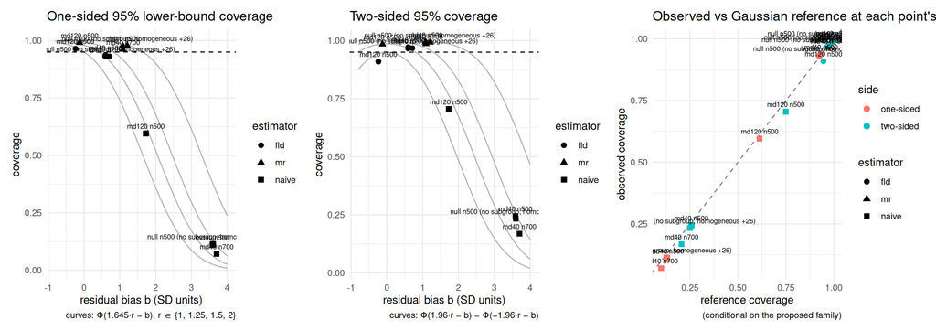

Hhat: bias against coverage on the identity scale, one point per estimator per cell. (conditional on the proposed family)

```r
DS$cell <- factor(DS$cell)
pH <- fs_plot_bias_coverage(DS[DS$block == "H", ], side = "lower") + ggplot2::labs(caption = COND)
ggsave(file.path(out_dir, sprintf("fig_%s_bias_coverage_display_H.png", tag)), pH, width = 13, height = 4.6, dpi = 130)
pH
```

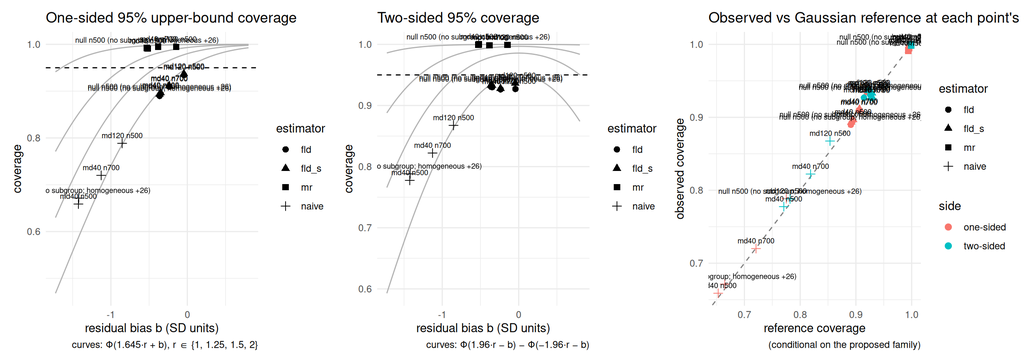

Hhat^c: bias against coverage on the identity scale, one point per estimator per cell; field-s through the renamed copy. (conditional on the proposed family)

```r
pC <- fs_plot_bias_coverage(DS[DS$block == "Hc", ], side = "upper") + ggplot2::labs(caption = COND)
ggsave(file.path(out_dir, sprintf("fig_%s_bias_coverage_display_Hc.png", tag)), pC, width = 13, height = 4.6, dpi = 130)
pC
```

# 10 The extract

```r
X <- do.call(rbind, EX)
gi <- X$identifier == "dina"
X$value[gi] <- signif(X$value[gi], 8); X$mc_se[gi] <- signif(X$mc_se[gi], 6); X$wilson_lo[gi] <- signif(X$wilson_lo[gi], 6); X$wilson_hi[gi] <- signif(X$wilson_hi[gi], 6)
write.csv(X, file.path(out_dir, "md_dina_metrics.csv"), row.names = FALSE, na = "")
cols <- c(
"# COLUMNS — md_dina_metrics.csv (campaign mddina; TASK_md_dina_campaign_2026-09-17 §3.2)", "",
"Written by `summary_continuous_field_mddina.qmd` from the same objects its tables print. The schema of `md_grf_metrics.csv` (see `COLUMNS_md_grf.md`, itself `md_field_metrics.csv`'s plus `identifier`). One row per cell × block × estimator × metric (× tau for bound-location rows).", "",
"## Columns", "",
"- `campaign`: `mddina`; `mdsgnb20` for the FS comparator rows; `mdgrf` for the GRF comparator rows.",
"- `identifier`: `dina` (this campaign); `fs` for the FS comparator rows, copied from the committed `md_field_metrics.csv`; `grf` for the GRF comparator rows, copied from the committed `md_grf_metrics.csv`. Comparator rows keep their own `commit` and are not recomputed.",
"- `cell`: `md40 n500`, `md120 n500`, `null n500 (no subgroup; homogeneous +26)`, `md40 n700`.",
"- `block`: `H` (the selected subgroup Ĥ), `Hc` (its complement Ĥᶜ), `joint` (the pair), `all` (timing).",
"- `estimator`, `metric`, `tau`, `value`, `mc_se`, `wilson_lo`, `wilson_hi`, `n`: as in `COLUMNS_md_field.md`.",
"- `commit`: the commit that added the cell's combined bundle (for `fs` and `grf` rows, the value in the committed extract).", "",
"## Estimator codes", "",
"`naive`, `oracle`, `mr`, `fld`, `fld_s`, `bonf_s`, `bonf`, `separate_s`, `calibrated`, `all`: as in `COLUMNS_md_field.md`, applied to the DINA-selected Ĥ.", "",
"## Metrics", "",
"As in `COLUMNS_md_grf.md` (itself `COLUMNS_md_field.md`), with these identification rows:", "",
"- `mean_size_hhat`: mean |Ĥ| over declared replicates (the recorder's `n_sel`; its `n_harm` is the same count, the size of Ĥ, not a true-positive count).",
"- `mean_true_positives`: mean number of truly harmed patients in Ĥ, sensitivity × `n_true`, over declared replicates with `n_true` > 0 (undefined in the null cell).",
"- `sensitivity_mean`, `ppv_mean`: the recorder's `sens`, `ppv` (`.classify`), mean over declared replicates.",
"- `mean_proposed_n`: mean of DINA's proposed family (`dina_proposed_n`: candidates with oriented tau-hat at or above the floor 30 and at least `n.min` members); `mean_n_family`: mean of MR's kept family size K; `mean_admitted_n`: mean of DINA's admitted set (proposed candidates whose harm-oriented MD clears the admission floor 30). All three over declared replicates: DINA's selection object, which carries the proposed and admitted counts, exists only when a subgroup is selected.",
"- `share_size_larger_than_fs`, `share_size_equal_than_fs`, `share_size_smaller_than_fs` and the matching `count_size_*_than_fs`: DINA's |Ĥ| against FS's (`mdsgnb20`) on the same `sim_id`, over replicates both identifiers declared.",
"- FS rows (`identifier = fs`): `declaration_rate`, `mean_n_sel`, `sensitivity_mean`, `ppv_mean`, and the three coverage rows of the three-identifier table (`H`/`fld`/`cov1_lower`, `Hc`/`fld_s`/`cov1_upper`, `joint`/`bonf_s`/`joint_coverage`). **FS's `mean_n_harm` equals its `mean_n_sel`** in `md_field_metrics.csv` (a labelling defect: `n_harm` is |Ĥ|, not a true-positive count); it is not copied.",
"- GRF rows (`identifier = grf`): `declaration_rate`, `mean_size_hhat`, `sensitivity_mean`, `ppv_mean`, `mean_n_family`, `mean_admitted_n`, and the same three coverage rows.",
"- `secs_fit_mr_mean`, `secs_field_mean`, `secs_complement_mean` (block `all`): mean seconds per replicate for the fit with MR (all replicates), the field pass and the complement field (declared replicates), as the regime table prints them; `fit_mr_secs` contains the other two, which are never summed.", "",
"## Scale convention", "",
"Every estimate, bound, bias and threshold is on the **harm-oriented mean-difference scale** (positive = harm; adverse_outcome = FALSE); `betaHhat_*` in the bundles are raw cd4_change and are oriented with -1 here. The null cell's truth is a homogeneous +26.255 on this scale for every Ĥ and Ĥᶜ. **Every DINA and GRF coverage figure is coverage of the estimand conditional on the proposed family**: their candidate families are generated from fitted surfaces, so the fixed-family condition does not hold. FS's family is the prespecified cut grid. Comparisons across the three identifiers are descriptive: the identifier, the family construction and the detected set all differ. No significance language: bounds are read by location against the ladder.")
writeLines(cols, file.path(out_dir, "COLUMNS_md_dina.md"))
cat(sprintf("extract: %d rows (%d dina, %d fs, %d grf) -> %s ; %s\n", nrow(X), sum(gi), sum(X$identifier == "fs"), sum(X$identifier == "grf"), file.path(out_dir, "md_dina_metrics.csv"), file.path(out_dir, "COLUMNS_md_dina.md")))
```

```
extract: 1174 rows (1110 dina, 28 fs, 36 grf) -> ./md_dina_metrics.csv ; ./COLUMNS_md_dina.md
```